[← Back to homepage.](https://nchaiyack.github.io)

# Lab Notebook, Jul 14 2025: A failed attempt at a grayscale graphic-to-ASCII art converter using the CW-SSIM index

Author

Nick C

Published

July 14, 2025

I recently had need to create a series ASCII art logos for a `neofetch`-style “check out my computer specs” program. For example, from the [original documentation](https://github.com/dylanaraps/neofetch) for `neofetch`, consider the following Arch logo (MIT licensed):

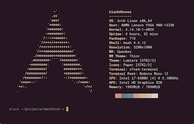

Of course, I don’t have any ASCII art skills. So why not let an algorithm convert it for you? The notebook below documents my **unsatisfactory** attempt at doing so via the following procedure:

1. Given a (grayscale) source image, first produce multiple slightly translated copies, to mitigate possible aliasing when converting to ASCII glyphs;
2. Divide the image up into equally-sized tiles;
3. Simultaneously, render ASCII glyphs to tiles of the same size;
4. Then match each tile to an ASCII glyph by using a well-known image similarity index with good properties. That is, match the tile to the ASCII glyph with the best similarity index.

In this case, as our image tile-to-ASCII-glyph matching metric, we use **Complex Wavelet Structural Similarity Index** (CW-SSIM), by Sampat, Wang, Gupta, Bovik, and Markey (2009), which is “robust to small rotations and translation”.

**Unfortunately**, the results aren’t satisfactory, as we’ll see at the end – not without producing too many alternative jittering renderings. Here are four jitterings of the Happy Mac, rendered as ASCII art 30 characters wide (including original border):

[figure not shown]

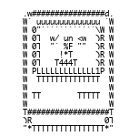

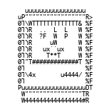

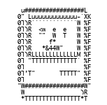

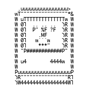

Here are some takeaway thoughts:

- Like optical font sizing, we have to be open to the possibility that the best smaller (lower-resolution) version of an image – logo, etc. – is not a direct resize, but a resize that takes into account aliasing and other visual effects. Is there a way of doing this computationally?
  - See Ahrens T. and Mugikura, S. (2014), [*Size-specific adjustments to type designs: An investigation of the principles guiding the design of optical sizes*](https://justanotherfoundry.com/size-specific-adjustments-to-type-designs).
- At very small sizes, we trade off clarity (i.e. being able to resolve features) with accuracy (i.e. keeping edges where they physically are). In this context, determining a single ASCII glyph therefore requires information from the entire image, rather than simply a single tile being converted (a “global” rather than “local” operation).
- A much more fruitful approach might be to use techniques from the “style transfer” literature. Perhaps, thinking wildly, a diffusion model might be the right computational technique.

## Preliminaries

```python
import ssim
```

```python
import array
from IPython.display import display
from PIL import ImageFont, Image, ImageDraw, ImageOps
from math import sqrt
import numpy as np
from math import floor, ceil
```

## Configuration

As input, we first allow RGB images, although ASCII rendering is eventually done in grayscale.

Our conversion process has the following knobs to tweak, beyond simply the source image (`SRC_IMAGE`) and source font (`SRC_FONT`):

- The # of columns in the resulting ASCII art;
- The character set to use, specified in `CHARSET`. ASCII is provided here, although another one of relevance to us is [Mac OS Roman](https://en.wikipedia.org/wiki/Mac_OS_Roman) used in the classic Macintosh OS.
- The RGB background colour, `BG_COLOR`,

There are other knobs we can twiddle as well:

1. We will need to figure out the aspect ratio of a single monospace glypth tile. To do so, `REFERENCE_CHAR`, `FONT_SIZE`, `FONT_WEIGHT`, and `DPI` are used to render a “reference glyph tile” – the pixel size is irrelevant.
2. To avoid aliasing issues, we divide the width and height of a glyph respectively into `X_TRANSLATED_ALTERNATIVES` increments, and `Y_TRANSLATED_ALTERNATIVES` increments. Then we translate the original image `X_TRANSLATED_ALTERNATIVES × Y_TRANSLATED_ALTERNATIVES` times These translations are by less than a width and height of an ASCII tile.
1. When translating the source image, we fill in the resulting empty space using the RGBA colour `BG_COLOR`.

```python
SRC_IMAGE = "./Happy_Mac_original-1.webp"
FONT = "./monaco.ttf"
```

```python
# Parameters re: output:
ASCII_ART_WIDTH = 30
CHARSET = " !\"#$%&'()*+,-./0123456789:;<=>?@ABCDEFGHIJKLMNOPQRSTUVWXYZ[\\]^_`abcdefghijklmnopqrstuvwxyz{|}~"
# An iumportant set of output parameters: we might worry about whether
# a sharp line perfectly lines up characters like slashes, lines, etc –
# - i.e. whether aliasing exists.
# So that we don't have to worry too much about this without reducing
# sharpness with antialiasing,
# we provide multiple alternative renderings by shifting the source image
# multiple times in the X and Y direction "less than the width of a cell";
# that way, we give lines multiple opportunities to line up with
# line characters etc.
X_TRANSLATED_ALTERNATIVES = 2;
Y_TRANSLATED_ALTERNATIVES = 2;
BG_COLOR = (255, 255, 255) # Currently only support clamp to border (colour).
    # However, I think ImageOps.pad will do clamping to edge .

# Expected parameters of the output terminal emulator.
FONT_SIZE = 9
FONT_WEIGHT = "normal"

# Internal parameters that tune internal calculations, but theoretically
# have no effect on the output.
REFERENCE_CHAR = "█"
TILESET_DPI = 300
```

## Image conversion

### Removing alpha + initial padding

After initial loading of image and font, we render a composite image of both to make sure we’ve removed the alpha channels from both correctly.

[figure not shown]

```python
# Load image and font directly into PIL; we will need to immediately convert
# the image from RGBA to RGB.
font = ImageFont.truetype(FONT, FONT_SIZE)
rgba_img = Image.open(SRC_IMAGE)

# Check if the image is in RGBA mode before attempting to split and composite.
if rgba_img.mode == 'RGBA':
  img = Image.composite(rgba_img, Image.new("RGB", rgba_img.size, BG_COLOR), rgba_img.split()[3])
else:
  img = rgba_img.convert("RGB") # Ensure it's in RGB mode

# Debug: display the image and example
# of the font rendered, composited
font_test = Image.new("RGB", (200, 200), (255, 255, 255))
font_test.paste(img, (0, 0))
font_ctx = ImageDraw.Draw(font_test)
font_ctx.text((0, 0), REFERENCE_CHAR + "Jackdaws ate my sphinx of quartz", font=font, fill=(0, 0, 0))
display(font_test)
```

**Important detail**: the final image we divide up into `ASCII_ART_WIDTH` tiles is *not actually* the original image, but the original image surrounded by a border the width of a tile.

Therefore, what we do is: - Divide the width of the original image into `ASCII_ART_WIDTH - 2` tiles (rounding up), obtaining `cell_w`, the pixel width of each tile.

- We obtain `cell_h`, the pixel height of each tile, by finding the aspect ratio of the font’s characters (i.e. using `REFERENCE_CHAR`) and multiplying by `cell_w` (rounding up);
- The resulting image we divide up into tiles is therefore created by adding a border of width `cell_w` and height `cell_h` around the image. The colour of this background is `BG_COLOR`.

At the end, we render a copy of the expanded image.

```python
# Important internal detail: because, to present multiple jittered alternative
# conversion to the user, we add an extra border around the image of 1 cell size
# each (hence adding +2 cells to total width and height), we internally need
# to subtract 2 when computing how to tilte the source image (sans border) only.
UNJITTERED_ASCII_ART_WIDTH = ASCII_ART_WIDTH - 2
```

```python
# Using UNJITTERED_ASCII_ART_WIDTH and the font parameters, compute the (pixel) width and
# height of an area covered by a single ASCII tile.
(_, _, old_img_w, old_img_h) = img.getbbox()
(_, _, refchar_w, refchar_h) = font.getbbox(REFERENCE_CHAR)
refchar_h_coef = refchar_h / refchar_w
cell_w = ceil(old_img_w / UNJITTERED_ASCII_ART_WIDTH)
cell_h = ceil(cell_w * refchar_h_coef)

# Then, calculate how many rows of ASCII art are needed to fully cover the
# source image with tiles; erring on the size of over-covering.
UNJITTERED_ASCII_ART_HEIGHT = ceil(old_img_h / cell_h)

# This tile width/height will likely not evenly
# divide the whole image -- in fact, celL_w and cell_h will result in
# an over-cover of the image -- so pad the image as needed.
padding_w = cell_w * UNJITTERED_ASCII_ART_WIDTH - old_img_w
padding_w_left = floor(padding_w / 2)
padding_w_right = ceil(padding_w / 2)
padding_h = cell_h * UNJITTERED_ASCII_ART_HEIGHT - old_img_h
padding_h_top = floor(padding_h / 2)
padding_h_bottom = ceil(padding_h / 2)

assert(cell_w * UNJITTERED_ASCII_ART_WIDTH == old_img_w + padding_w_left + padding_w_right)
assert(cell_h * UNJITTERED_ASCII_ART_HEIGHT == old_img_h + padding_h_top + padding_h_bottom)

## Okay; create a new image w/ padding.
padded_img = Image.new("RGB", (old_img_w + padding_w_left + padding_w_right, old_img_h + padding_h_top + padding_h_bottom), BG_COLOR)
padded_img.paste(img, (padding_w_left, padding_h_top))
img_w, img_h = padded_img.size

# We should have the following relations:
assert(img_w == UNJITTERED_ASCII_ART_WIDTH * cell_w)
assert(img_h == UNJITTERED_ASCII_ART_HEIGHT * cell_h)
```

```python
# Let (pixwidth, pixheight) be the (pixel) width and height of an area
# covered by a single ASCII tile. Expand the source image to create
# a border of width cell_w and cell_h - i.e. enough space for an
# extra cell on all sides.
expanded_img = Image.new("RGB", (img_w + 2*cell_w, img_h + 2*cell_h), BG_COLOR)
expanded_img.paste(padded_img, (cell_w, cell_h))
```

[figure not shown]

```python
display(expanded_img)
```

### Jittering the source image

Recall that, to mitigate the effects of ailasing due to image features incidentally lining up with ASCII tile boundaries, we jitter the image `X_TRANSLATED_ALTERNATIVES × Y_TRANSLATED_ALTERNATIVES` times. Specifically, to produce successive images, we repeatedly nudge by `x_jitter_stride` and/or `y_jitter_stride`; always by less than an ASCII tile’s pixel width and height.

At the end, we show all of our alternatives for the current setup of `X_TRANSLATED_ALTERNATIVES := 2` and `Y_TRANSLATED_ALTERNATIVES := 2`.

[figure not shown]

[figure not shown]

[figure not shown]

[figure not shown]

```python
# Define
# x_jitter_stride := cell_w / X_TRANSLATED_ALTERNATIVES, and
# y_jitter_stride := cell_h / Y_TRANSLATED_ALTERNATIVES.
x_jitter_stride = cell_w / X_TRANSLATED_ALTERNATIVES
y_jitter_stride = cell_h / Y_TRANSLATED_ALTERNATIVES

# Create two arrays - jittered_img contains jittered src images; jittered_img_arrs
# contains numpy equivalents of these arrays.
jittered_imgs = []

# Create multiple copies of the source image, each shifted by
# (x_jitter_stride * i, y_jitter_stride * j) for i in range(X_TRANSLATED_ALTERNATIVES)
# and j in range(Y_TRANSLATED_ALTERNATIVES), and again fill any pixels
# that fall outside the source image with the colour specified by
# BG_COLOR.
for i in range(X_TRANSLATED_ALTERNATIVES):
  for j in range(Y_TRANSLATED_ALTERNATIVES):
    to_add = Image.new("RGB", (expanded_img.width, expanded_img.height), BG_COLOR)
    to_add.paste(expanded_img, (int(i * x_jitter_stride), int(j * y_jitter_stride)))
    jittered_imgs.append(to_add)

for jittered_img in jittered_imgs:
    display(jittered_img)
```

### Tileset creation

Separately, given `cell_w` and `cell_h`, the target pixel dimensions of a tile, we generate a “tileset” of renderings (currently RGB) of characters in `CHARSET` into tiles with pixel dimensions. Result: `tileset_char[]` gives each character in order, and `tileset_img[]` gives in the same order each corresponding rentered character tile. This is what we will match each tile to.

```python
# Create a struct-of-array "dictionary" takes each of the characters in CHARSET
# to an image of size cell_w, cell_h, containing font rendered in grayscale, sized to
# exactly fit the cell. (If the rendering doesn't produce the exact
# size, scale to take care of implicit antialiasing.)
tileset_char = []
tileset_img = []

for char in CHARSET:
    temp_img = Image.new("RGBA", (refchar_w, refchar_h), (255, 255, 255, 255))
    font_ctx = ImageDraw.Draw(temp_img)
    font_ctx.text((0, 0), char, font=font, fill=(0, 0, 0, 255))
    temp_img = temp_img.resize((cell_w, cell_h), Image.HAMMING)
    tileset_char.append(char)
    tileset_img.append(temp_img)

# Debug: show all images in 'tileset'.
for one_tile in tileset_img[0:3]:
  display(one_tile)
```

### Tiling the image

**Technical decision:** for the purposes of iterating over successive tiles, we work with (grayscale) images in `numpy` array form (after converting to grayscale.) As a result, it becomes easy to iterate through axis-aligned subarrays of 2D tiles (`iterate_tiles`), as well as flatten tiles (`linearize_tile`, `iterate_linearized_tiles`), although we don’t end up needing to use this.

The next code chunk defines tile iteration functions; the code chunk after that does actual conversion of both jittered images and ASCII styles to grayscale.

```python
def linearize_tile(nparray, width, height):
  assert(nparray.shape[0] == height)
  assert(nparray.shape[1] == width)
  return nparray.flatten()

def iterate_tiles(nparray, numtilesw, numtilesh, tilewidth, tileheight):
  assert(nparray.shape[0] == numtilesh * tileheight)
  assert(nparray.shape[1] == numtilesw * tilewidth)
  for i in range(numtilesh):
    for j in range(numtilesw):
      yield nparray[i*tileheight:(i+1)*tileheight, j*tilewidth:(j+1)*tilewidth]

def iterate_linearized_tiles(nparray, numtilesw, numtilesh, tilewidth, tileheight):
  for tile in iterate_tiles(nparray, numtilesw, numtilesh, tilewidth, tileheight):
    yield linearize_tile(tile, tilewidth, tileheight)
```

```python
jitteredimgs_bwarrays = []
for jittered_img in jittered_imgs:
  jitteredimgs_bwarrays.append(np.array(jittered_img.convert("L")))

tileset_bwarrays = []
for tile in tileset_img:
  tileset_bwarrays.append(np.array(tile.convert("L")))
```

### Metric-maximizing ASCII art rendering

With all of these definitions, the actual source image tile-to-ASCII-glyph matching is straightforward. The function `tile_metric(tile1, tile2)` provides a simple wrapper of a routine that comutes CW-SSIM metric on tiles. (Note that the underlying implementation in `pyssim` requires PIL images).

Then, we do the following iterations to map all of our jittered images to ASCII art tiles:

- For each jittered alternative source image;
  - For each tile in the jittered source image; successively compare the current tile all ASCII glyph tiles, by computing CW-SSIM index. Retain the ASCII glyph that has the highest CW-SSIM metric (i.e. similarity index).

Given our 4 jittered alternatives, the resulting “best” ASCII translations are rendered at the end. We then subjectively evaluate them.

```python
def tile_metric(tile1, tile2):
  img1 = ssim.SSIM(Image.fromarray(tile1))
  return img1.cw_ssim_value(Image.fromarray(tile2))
```

[output not shown]

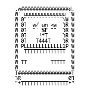

[output not shown]

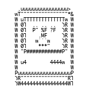

[output not shown]

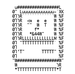

[output not shown]

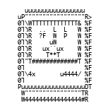

```python
# For each jittered img;
for img_i, img_array in enumerate(jitteredimgs_bwarrays):
  chars = []
  # For each tile;
  for tile_i, tile in enumerate(iterate_tiles(img_array, UNJITTERED_ASCII_ART_WIDTH + 2, UNJITTERED_ASCII_ART_HEIGHT + 2, cell_w, cell_h)):
    tile_history = []
    # For each potential character;
    for i in range(len(tileset_bwarrays)):
      print(f't {tile_i} c {tileset_char[i]}', end = " ")
      # Compute loss;
      loss = tile_metric(tile, tileset_bwarrays[i])
      tile_history.append((tileset_char[i], tile_metric(tile, tileset_bwarrays[i])))
    # Sort tile_history by descending value of tile metric;
    tile_history.sort(key=lambda x: x[1], reverse=True)
    # Append current rendered char to 'chars'
    chars.append(tile_history[0][0])
  # Here is a way to visualize our output.
  # Recreate the jittered image from img_array;
  ascii_rendering = Image.new("L", (jittered_imgs[img_i].height, jittered_imgs[img_i].width), 255)
  # For each tile index;
  for i in range(UNJITTERED_ASCII_ART_WIDTH + 2):
    for j in range(UNJITTERED_ASCII_ART_HEIGHT + 2):
      # Recreate the associated character's image;
      tile_idx = tileset_char.index(chars[j * (UNJITTERED_ASCII_ART_WIDTH + 2) + i])
      tile_img = Image.fromarray(tileset_bwarrays[tile_idx].reshape((cell_h, cell_w)))
      # Paste in the pixel location.
      ascii_rendering.paste(tile_img, (i * cell_w, j * cell_h))
  display(ascii_rendering)
```

**Evaluating our results.** Although our resulting images are recognizable Happy Macs, they are very coarse renderings of the original image – not enough to resolve the “face” of the Happy Mac in a recognizable way, for example. Jittering the image provided more clearer alternatives (or at least rendered certain features more clearly), but 4 alternatives isnt’ enough here to produce an image with good resolution.

In fact, we have to be open to the possibility of something other than a 1:1 tile-to-ASCII image translation – perhaps by an initial “optical resizing”/feature-adjusting step.